# Applications of Inference Frameworks

Last updated: 2017-02-07

## Notes

## Readings

## Frameworks for inference

1. Analytical
2. Maximum likelihood
3. Resampling
4. Bayesian

## Linear regression

What values of \(\theta_1\) and \(\theta_2\) provide the best fit line through \(Y\) as a function of \(X\)?

\[Y = \theta_1 + \theta_2 X\]

How do we estimate \(\theta_1\) and \(\theta_2\)?

## Generate data

Generate \(n=30\) random data points: \(X \sim \mathcal{N}(10, 1)\) and \(Y = 2.3 X + \epsilon\), where \(\epsilon \sim \mathcal{N}(1, 1)\):

```r
set.seed(4)
n <- 30
X <- rnorm(n, mean = 10, sd = 1)
Y <- 2.3 * X + rnorm(n, mean = 1, sd = 1)
M <- data.frame(X, Y)
M %>% head()
```

```
##           X        Y
## 1 10.216755 24.65200
## 2  9.457507 23.80420
## 3 10.891145 25.29542
## 4 10.595981 23.88857
## 5 11.635618 28.62305
## 6 10.689275 25.18081
```

## Generate data

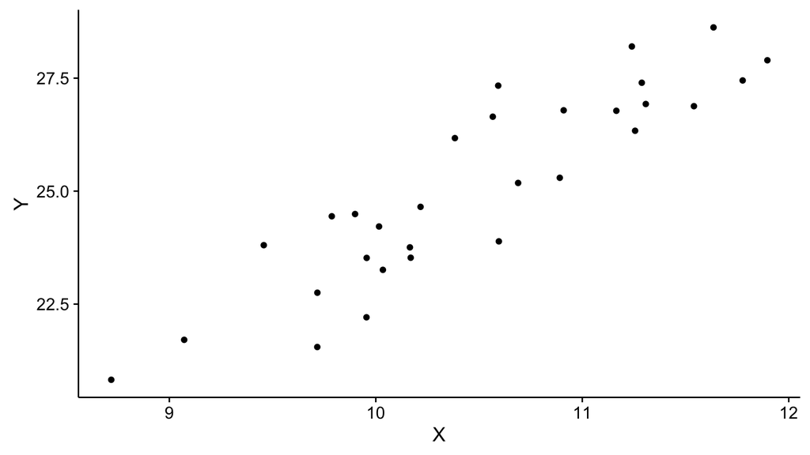

## Analytical solution 1

An infinite range of possible slopes (\(\theta_1\))

1. All pass through \(\left(\bar{X}, \bar{Y}\right)\).
2. Sum of the squared deviations vary continuously.
3. Only one value of \(\theta_1\) will minimize the SS.
   - The *Ordinary Least Squares* estimate

## Analytical calculation of \(\theta_1\)

\[\theta_1 = \frac{\sum\left(X_{i}-\bar{X}\right)\left(Y_{i}-\bar{Y}\right)}{\sum\left(X_{i}-\bar{X}\right)^{2}}\]

Numerator: Sum of the products of *X* and *Y*

Denominator: Sum of squares of *X*

## Another analytical calculation of \(\theta_1\)

The covariance of *X* and *Y* divided by the variance of *X*.

\[\theta_1 = \frac{Cov(X, Y)}{s_X^2}\]

\[Cov(X, Y) = \frac{\sum\left(X_{i}-\bar{X}\right)\left(Y_{i}-\bar{Y}\right)}{n - 1}\]

\[s_x^2 = \frac{\sum\left(X_{i}-\bar{X}\right)^{2}}{n - 1}\]

## Analytical calculation of \(\theta_0\)

Because the OLS line must pass through \(\left(\bar{X},\bar{Y}\right)\):

\[\theta_0 = \bar{Y} - \theta_1 \bar{X}\]

## Comparison to correlation

\[r = \frac{\sum\left(X_i - \bar{X}\right)\left(Y_i - \bar{Y}\right)}{\sqrt{\sum\left(X_i - \bar{X}\right)^{2}}\sqrt{\sum\left(Y_i - \bar{Y}\right)^{2}}}\]

\[\theta_1 = \frac{\sum\left(X_{i} - \bar{X}\right)\left(Y_{i} - \bar{Y}\right)}{\sum\left(X_{i} - \bar{X}\right)^{2}}\]

\[\theta_1 = r_{X,Y}\frac{s_Y}{s_X}\]

## Assumptions of OLS

At each *X*, there is a normally distributed population of *Y* observations with a mean at the regression line

- The variance of all *Y* observations is equal.

No assumptions are made about *X*

- Not that it is normal
- Not that it is randomly sampled
- Think about calibration curves. You set the *X* observations explicitly.

## Normally distributed population of *Y* observations

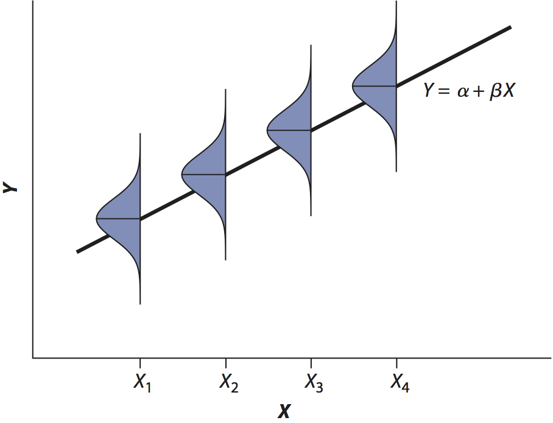

## Minimizing Sums of Squares

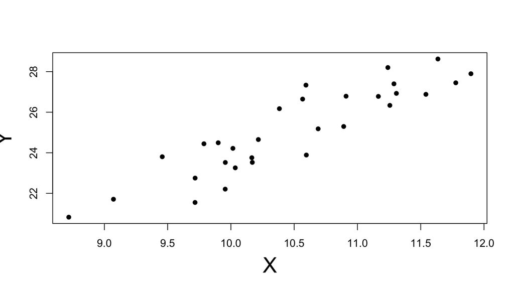

## Minimizing Sums of Squares

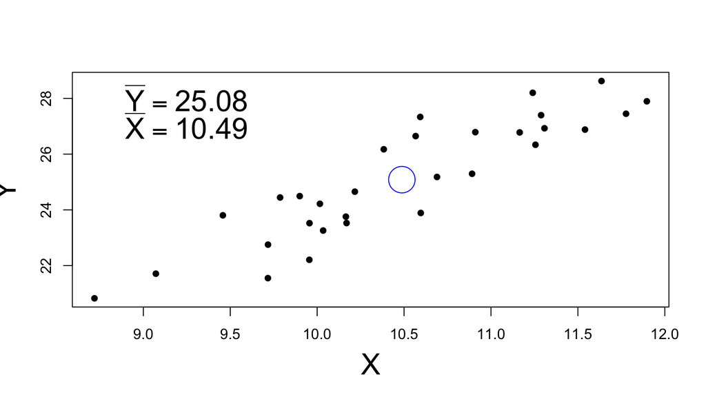

## Minimizing Sums of Squares

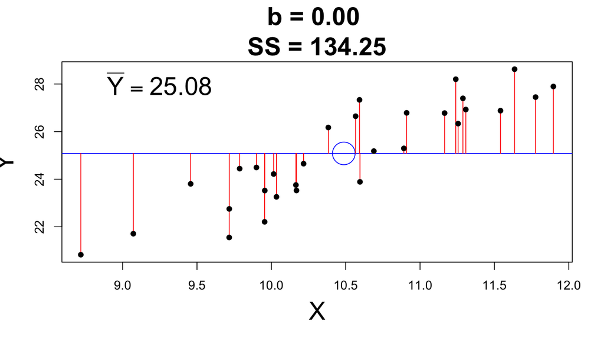

## Minimizing Sums of Squares

\[SS = \sum\left(Y_i - \hat{Y}\right)^2\]

Where:

- \(Y_i\) are the observed values of \(Y\)
- \(\hat{Y}\) are the predicted values of \(Y\) for each \(X\). (Note analogy between predicted values and sample mean.)

## Minimizing Sums of Squares

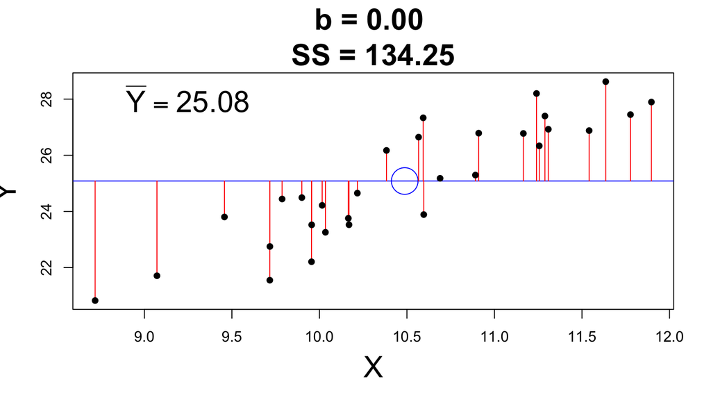

## Minimizing Sums of Squares

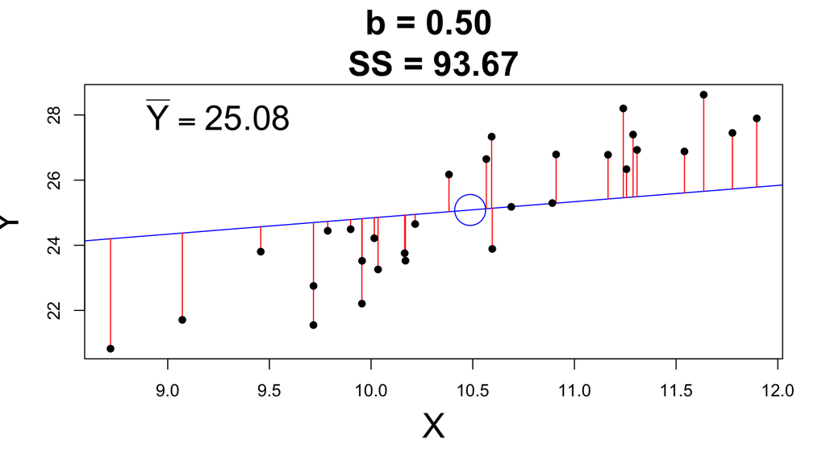

## Minimizing Sums of Squares

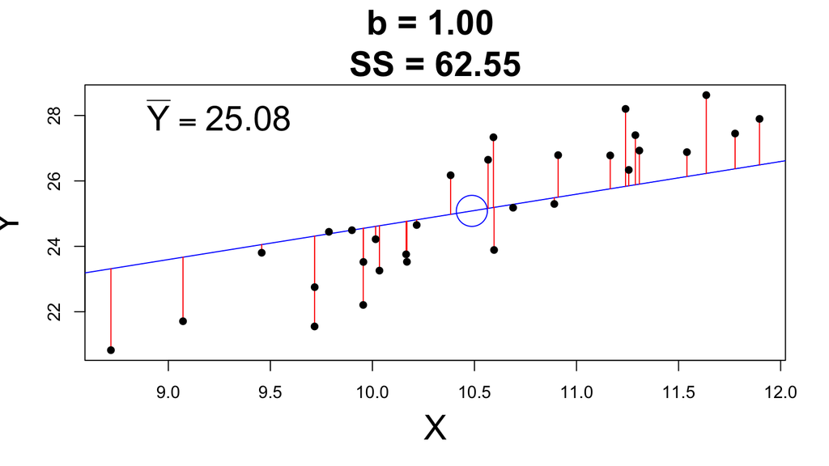

## Minimizing Sums of Squares

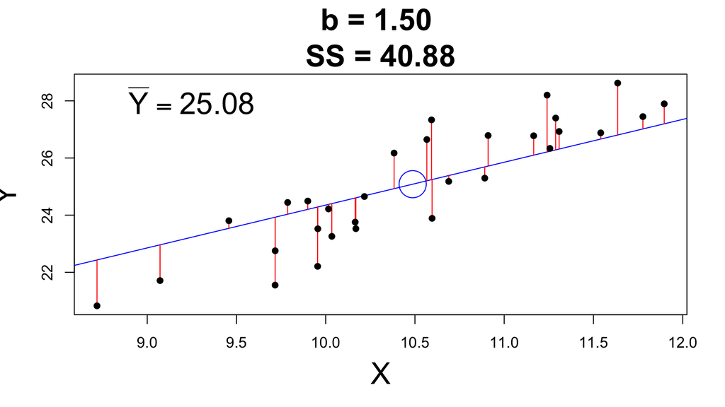

## Minimizing Sums of Squares

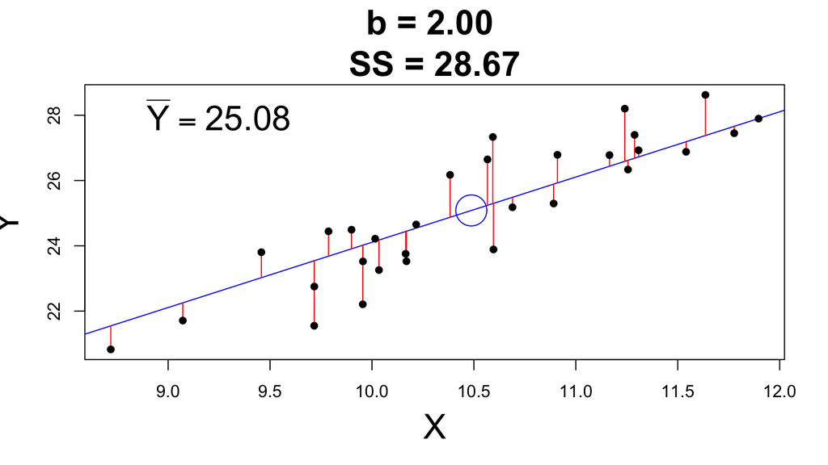

## Minimizing Sums of Squares

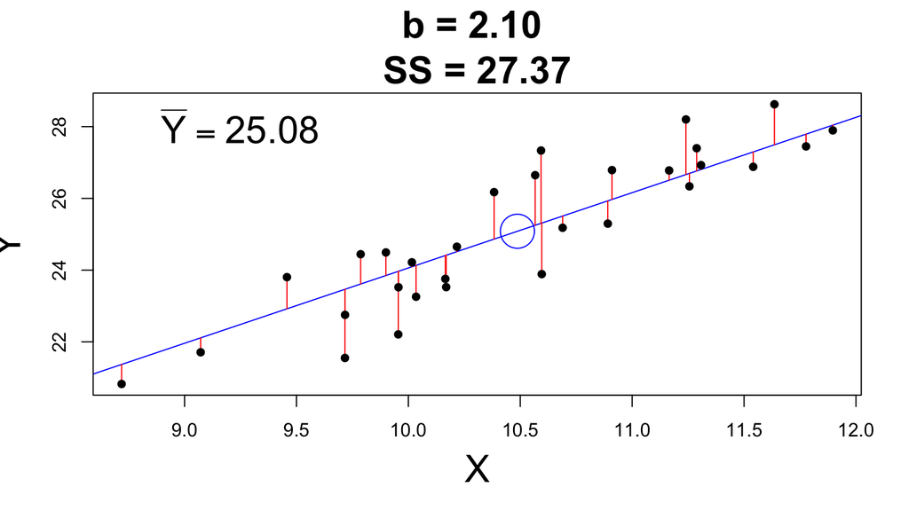

## Minimizing Sums of Squares

```r
# Iteratively find the minimum SS
theta_1 <- seq(-10, 10, by = 0.01)

# data.frame to hold output
SumSq <- data.frame(theta_1 = theta_1,
                    SS = numeric(length(theta_1)))
head(SumSq)
```

```
##   theta_1 SS
## 1  -10.00  0
## 2   -9.99  0
## 3   -9.98  0
## 4   -9.97  0
## 5   -9.96  0
## 6   -9.95  0
```

## Minimizing Sums of Squares

```r
# Iterate through slopes
for (i in 1:nrow(SumSq)) {
  theta_1 <- SumSq$theta_1[i]
  SumSq$SS[i] <- ssPlot(X, Y, theta_1, do.plot = FALSE)
}

# Location of minimum SS
minSS.theta_1 <- SumSq$theta_1[which.min(SumSq$SS)]
minSS.SS <- SumSq$SS[which.min(SumSq$SS)]
```

## Minimizing Sums of Squares

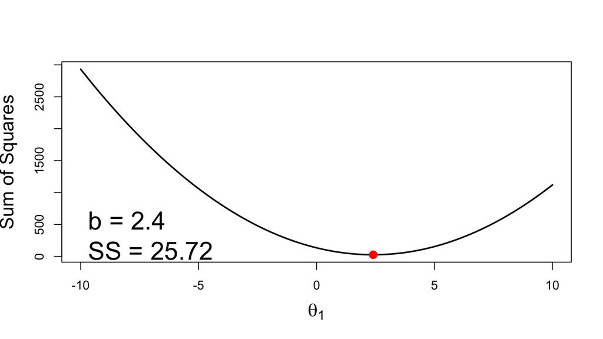

## Analytical solution 2: Matrix algebra

\(Y\) is a (\(n \times 1\)) vector of observed values \(X\) is an (\(n \times 2\)) matrix of ones followed by observations

\[\theta = (X'X)^{-1} X'Y\]

Where \(X'\) is the transpose of \(X\) and \(X^{-1}\) is the inverse.

```r
(X_mat <- matrix(c(rep(1, n), X), ncol = 2))
```

```
##       [,1]      [,2]
##  [1,]    1 10.216755
##  [2,]    1  9.457507
##  [3,]    1 10.891145
##  [4,]    1 10.595981
##  [5,]    1 11.635618
##  [6,]    1 10.689275
##  [7,]    1  8.718753
##  [8,]    1  9.786855
##  [9,]    1 11.896540
## [10,]    1 11.776863
## [11,]    1 10.566604
## [12,]    1 10.015719
## [13,]    1 10.383057
## [14,]    1  9.954863
```

[output cut: 16 more lines]

## Analytical solution 2

```r
(theta <- (solve(t(X_mat) %*% X_mat)) %*% (t(X_mat) %*% Y))
```

```
##             [,1]
## [1,] -0.03540546
## [2,]  2.39524849
```

`theta` is a 2 x 1 matrix of coefficients:

\[ \theta=\left[\begin{array}{c} -0.035\\ 2.395 \end{array}\right] \]

```r
lm_fast <- function(X, Y) {
  X_mat <- matrix(cbind(rep(1, length(Y)), X), nrow = length(Y))
  theta <- (solve(t(X_mat) %*% X_mat, tol = 1e-25)) %*% (t(X_mat) %*% Y)
  return(theta)
}

predict_Y <- function(theta, X) {
  X <- as.matrix(X, nrow = length(theta))
  Y_hat <- theta[1, 1] + rowSums(theta[2:nrow(theta), 1] * X)
  return(Y_hat)
}

log_lik <- function(Y, Y_hat) {
  var_hat <- sum((Y - Y_hat)^2) / (length(Y))
  sd_hat <- sqrt(var_hat)
  probs_Y <- dnorm(Y, mean = Y_hat, sd = sd_hat)
  LL <- sum(log(probs_Y))
  return(LL)
}
```

```r
theta <- lm_fast(X, Y)
Y_hat <- predict_Y(theta, X)
(LL <- log_lik(Y, Y_hat))
```

```
## [1] -40.25821
```

```r
fm <- lm(Y~X)
logLik(fm)
```

```
## 'log Lik.' -40.25821 (df=3)
```

```r
X_mat <- matrix(c(rep(1, length(X)), X), ncol = 2)
fm_fast <- fastLmPure(X_mat, as.matrix(Y))
log_lik(Y, fm_fast$fitted.values)
```

```
## [1] -40.25821
```

```r
t1 <- Sys.time()

reps <- 10^4
liks <- numeric(length = reps)

load("~/Dropbox/House/Aprob.rda")
n <- nrow(Aprob)

# Add column of 1's for intercept term
X <- as.matrix(cbind(rep(1, n), Aprob[, 2:9]), nrow = n)

set.seed(5)

for (i in 1:reps) {
  Y <- rexp(n, rate = 10)

  # Normalize so each row sums to 1.
  fm_fast <- fastLmPure(X, Y)
  liks[i] <- log_lik(Y, fm_fast$fitted.values)
}
Sys.time() - t1
```

```
## Time difference of 3.903587 secs
```

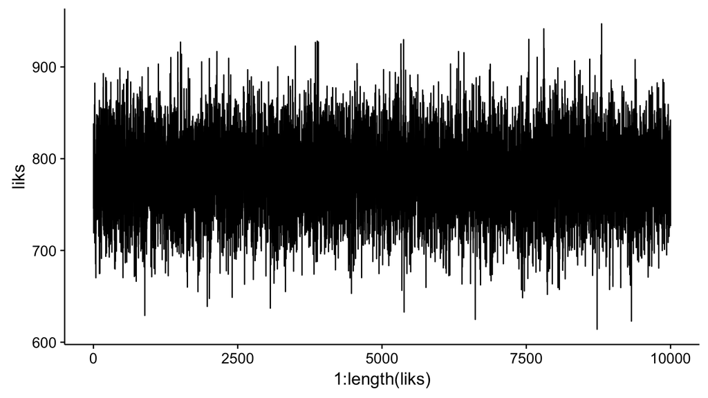

```r
ggplot(as.data.frame(liks), aes(x = 1:length(liks), y = liks)) +
  geom_path()
```

```r
library(modelr)
fm <- lm(Y ~ X, data = M)
M_aug <- M %>%
  add_residuals(fm) %>%
  add_predictions(fm)
M_aug
```

```
##            X        Y       resid     pred
## 1  10.216755 24.65200  0.21573922 24.43626
## 2   9.457507 23.80420  1.18652478 22.61767
## 3  10.891145 25.29542 -0.75617078 26.05159
## 4  10.595981 23.88857 -1.45603476 25.34460
## 5  11.635618 28.62305  0.78826234 27.83479
## 6  10.689275 25.18081 -0.38725166 25.56807
## 7   8.718753 20.82573 -0.02244801 20.84818
## 8   9.786855 24.44386  1.03731847 23.40655
## 9  11.896540 27.89615 -0.56361782 28.45976
## 10 11.776863 27.44924 -0.72386642 28.17311
## 11 10.566604 26.64690  1.37266101 25.27424
## 12 10.015719 24.21769  0.26295874 23.95473
## 13 10.383057 26.17354  1.33894731 24.83460
## 14  9.954863 22.20814 -1.60082873 23.80896
```

[output cut: 16 more lines]

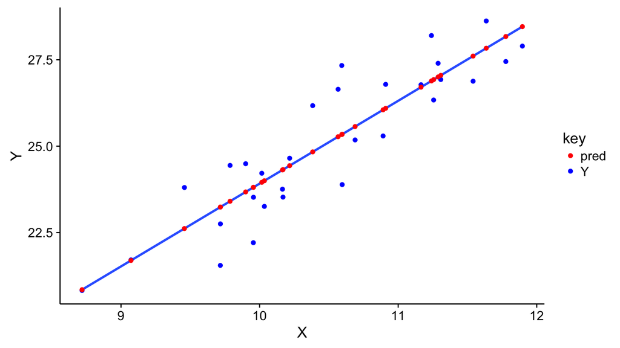

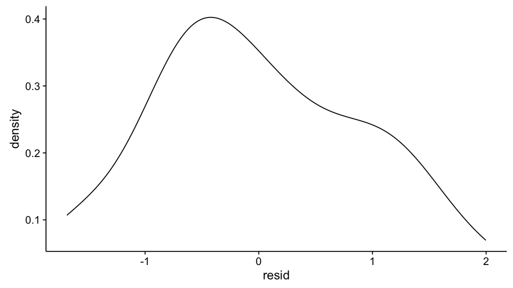

```
##     Min.  1st Qu.   Median     Mean  3rd Qu.     Max.
## -1.68700 -0.69020 -0.07185  0.00000  0.76430  1.99700
```

## Maximum likelihood

## Minimizing the SS == Maximizing the Likelihood

Minimizing the residual sum of squares is numerically equal to *maximizing* the model likelihood.

## Errors are normally distributed around the regression line

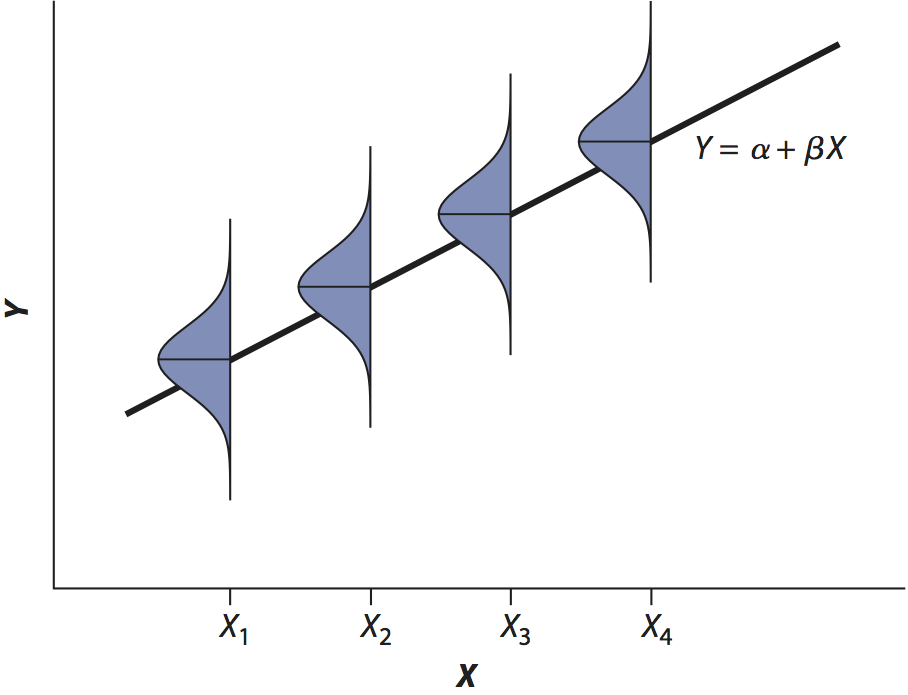

How would probabilities change for a different slope estimate?

## What is the probability of an observed value given a regression model?

Define a function to calculate the probability of an observed value \(Y_i\) given the mean (\(\mu\)) and standard deviation (\(\sigma\)). Default to the standard normal distribution \(\mathcal{N}(0,1)\).

\[\phi\left(Y_i\right) = \frac{1}{\sqrt{2\pi\sigma^{2}}} e^{\frac{-\left(Y_i-\mu\right)^{2}}{2\sigma^{2}}}\]

```r
normal <- function(Y, mu = 0, sigma = 1) {
  1 / sqrt(2 * pi * sigma ^ 2) *
    exp((-(Y - mu) ^ 2 / (2 * sigma ^ 2)))
}
```

*Note*: this function is built into R as `dnorm()`.

## Check that our function works

```r
normal(0, mu = 0, sigma = 1)
```

```
## [1] 0.3989423
```

```r
dnorm(0, 0, 1)
```

```
## [1] 0.3989423
```

```r
normal(1, mu = 0, sigma = 1)
```

```
## [1] 0.2419707
```

```r
dnorm(1, 0, 1)
```

```
## [1] 0.2419707
```

## Define a model

\[y = \bar{Y} + bX\]

\[b = 0\]

This is a flat line (\(b = 0\)) through the mean of \(Y\).

## Define a model

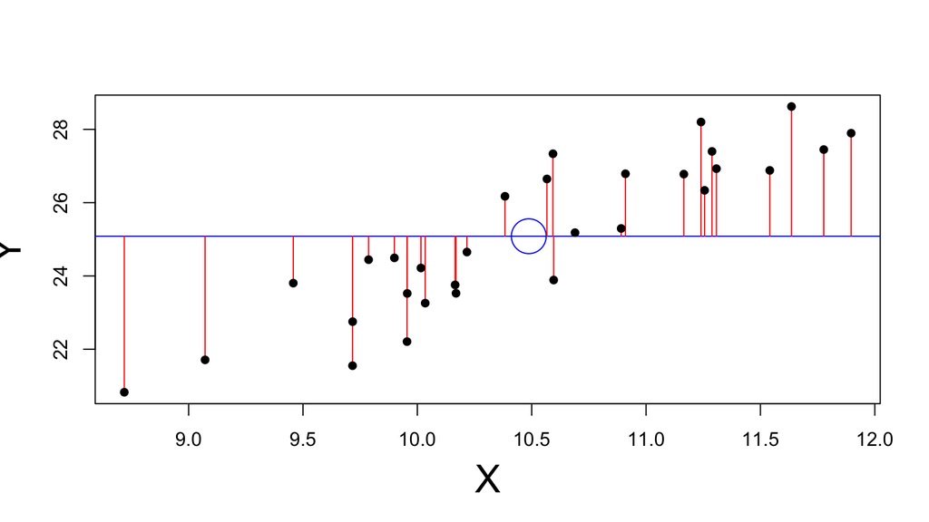

## Calculate the predicted values

Just the mean of \(Y\) repeated 30 times.

```r
Y_bar <- mean(Y)
Y_hat <- rep(Y_bar, length(Y))
Y_hat
```

```
##  [1] 25.08401 25.08401 25.08401 25.08401 25.08401 25.08401 25.08401
##  [8] 25.08401 25.08401 25.08401 25.08401 25.08401 25.08401 25.08401
## [15] 25.08401 25.08401 25.08401 25.08401 25.08401 25.08401 25.08401
## [22] 25.08401 25.08401 25.08401 25.08401 25.08401 25.08401 25.08401
## [29] 25.08401 25.08401
```

## Probability of a predicted value of \(Y\)

\[\phi\left(Y_i\right)=\frac{1}{\sqrt{2\pi\hat{\sigma}^2}} e^{\frac{-\left(Y_i - \mu\right)^{2}}{2\hat{\sigma}^2}}\]

- \(\mu =\) the predicted value \(\hat{Y}_i\)
- Need the estimate of the residual variance \(\left(\hat{\sigma}^2\right)\).

## Residual variance

\[\hat{\sigma}^2 = \frac{\Sigma_i\left(Y_i - \hat{Y}_i\right)^2}{n}\]

This is a biased estimate, but that's ok. It is how model likelihoods are calculated in this case.

\[s^2 = MSE = \frac{n}{n-2}\left(\hat{\sigma}^2\right)\]

For non-small \(n\), \(s^2 \approx \left(\hat{\sigma}^2\right)\). Here ~7% difference.

## Calculate the estimated residual variance and standard deviation

```r
# Estimated variance
var_hat <- sum((Y - Y_hat)^2) / (length(Y))
var_hat
```

```
## [1] 4.475126
```

```r
sd_hat <- sqrt(var_hat)
sd_hat
```

```
## [1] 2.115449
```

## Probability for observed \(Y\)s

```r
# Check the probability for the first Y
normal(Y[1], mu = Y_hat[1], sigma = sd_hat)
```

```
## [1] 0.1846934
```

```r
# Calculate for all Ys
probs_Y <- normal(Y, mu = Y_hat, sigma = sd_hat)
probs_Y
```

```
##  [1] 0.18469336 0.15704719 0.18764577 0.16075453 0.04653338 0.18838780
##  [7] 0.02486777 0.18014534 0.07794390 0.10093788 0.14354376 0.17341633
## [13] 0.16516072 0.07484938 0.12993261 0.14381858 0.13683565 0.14362128
## [19] 0.18136842 0.04674421 0.13151337 0.15486450 0.12898315 0.10364549
## [25] 0.10708752 0.10273798 0.15828717 0.13630709 0.05285416 0.06367672
```

OK. Now what?

## Model Likelihood (\(\mathcal{L}\))

For a set of \(Y_i\) and parameters (\(\Theta\); i.e., slope and intercept) the likelihood of the model is the product of their individual probabilities:

\[\mathcal{L}\left(\left\{ Y_{i}\right\} _{i=1}^{n};\Theta\right) = \prod_{i=1}^{n}\phi\left(Y_{i}; \Theta\right)\]

Evaluate the likelihood function for different values of \(\Theta\) to estimate \(\mathcal{L}\) for different sets of \(\Theta\).

- Maximize \(\mathcal{L}\) and you will have the best set of parameter estimates.

## Model Likelihood (\(\mathcal{L}\))

Log both sides of the equation:

\[\log\left(\mathcal{L}\left(\left\{ Y_{i}\right\} _{i=1}^{n};\Theta\right)\right) = \log\left(\prod_{i=1}^{n}\phi\left(Y_{i};\Theta\right)\right)\]

## Model Likelihood (\(\mathcal{L}\))

Taking advantage of the algebraic rules associated with logs (the log of the products equals the sum of the logs):

\[\log\left(\mathcal{L}\left(\left\{ Y_{i}\right\} _{i=1}^{n};\Theta\right)\right) = \sum_{i=1}^{n} \log\left(\phi\left(Y_{i};\Theta\right)\right)\]

So we just need to sum the log-likelihoods to get the overall model likelihood.

*Note*: `log()` is *natural* log.

## Model Likelihood (\(\mathcal{L}\))

```r
# Product of the individual likelihoods
prod(probs_Y)
```

```
## [1] 5.63386e-29
```

This is a very small number (and we only have 30 observations).

```r
# Sum of the log-likelihoods
sum(log(probs_Y))
```

```
## [1] -65.04617
```

This number is easier to deal with.

## Likelihood from linear regression with \(b = 0\)

Fit a linear model (`lm()`) with only an intercept (`~ 1`) and use the built-in function `logLik()` to extract the log-likelihood.

```r
fm <- lm(Y ~ 1)
ll <- logLik(fm)
ll
```

```
## 'log Lik.' -65.04617 (df=2)
```

```r
exp(ll)
```

```
## 'log Lik.' 5.63386e-29 (df=2)
```

## Maximizing the log-Likelihood

Function to calculate the log-likelihood. Input the slope (\(b\)) and observed values of \(X\) and \(Y\). Return the log-likelihood.

```r
log_lik <- function(b, X, Y){
  Y_bar <- mean(Y)
  X_bar <- mean(X)
  a <- Y_bar - b * X_bar
  Y_hat <- a + b * X
  var_hat <- sum((Y - Y_hat)^2) / (length(Y))
  sd_hat <- sqrt(var_hat)
  probs_Y <- normal(Y, mu = Y_hat, sigma = sd_hat)
  return(sum(log(probs_Y)))
}
```

## Maximizing the log-Likelihood

For a range of \(b\) from -10 to 10 in increments of 0.01, calculate the log-likelihood of the model. Save to a variable called `lls`. Then find the maximum value of `lls`, the associated \(b\) and log-likelihood.

```r
b <- seq(-10, 10, by = 0.01)
lls <- numeric(length(b))
for (i in 1:length(b)) {
  lls[i] <- log_lik(b[i], X, Y)
}

# Location of maximum log-likelihood
max.ll <- lls[which.max(lls)]

# Slope at maximum log-likelihood
b_hat <- b[which.max(lls)]
```

## Maximizing the log-Likelihood

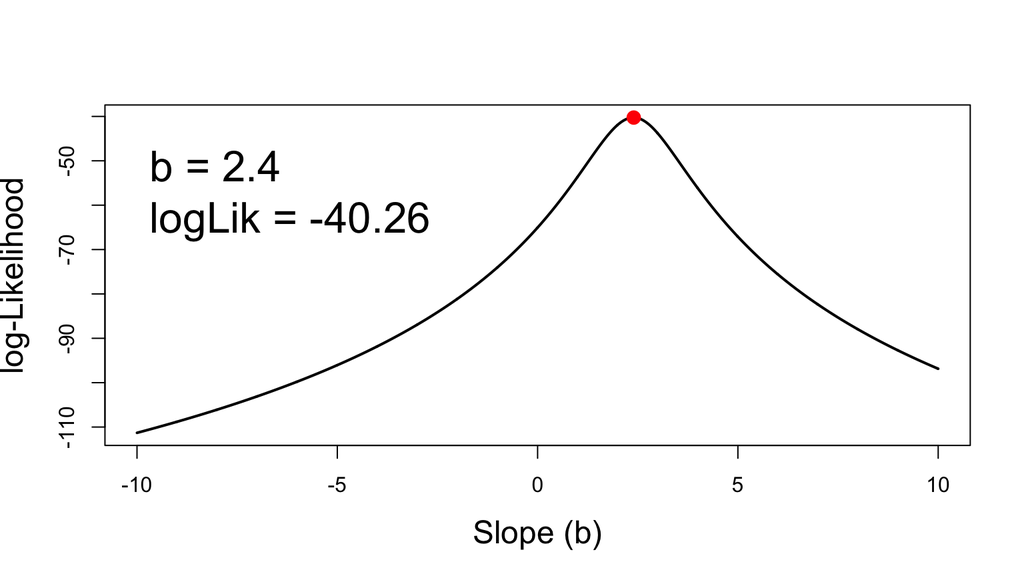

## Maximizing the log-Likelihood

```r
max.ll
```

```
## [1] -40.25846
```

```r
fm <- lm(Y ~ X) # Fit model with slope and intercept
logLik(fm)      # Use built-in function to extract log-likelihood
```

```
## 'log Lik.' -40.25821 (df=3)
```

The values are not identical, because we only calculated \(b\) in increments of 0.01.

*Can we be more accurate?*

## Optimizing the log-Likelihood

`optimize()` finds the maximum or minimum of a function given a range of values to test (`interval`).

```r
optimize(log_lik, interval = c(-10, 10),
         X = X, Y = Y,
         maximum = TRUE)
```

```
## $maximum
## [1] 2.39525
##
## $objective
## [1] -40.25821
```

```r
logLik(fm)
```

```
## 'log Lik.' -40.25821 (df=3)
```

## Bayesian

What priors for intercept (\(\theta_0\)) and slope (\(\theta_1\))?

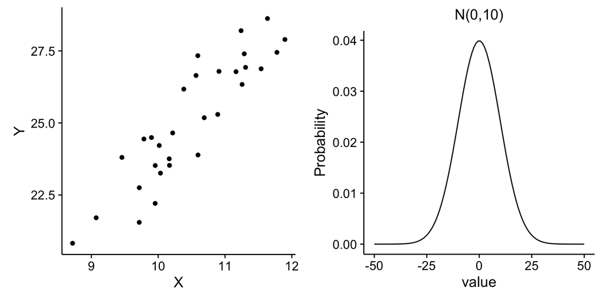

## Bayesian

```r
fm <- map2stan(
  alist(
    Y ~ dnorm(mu, sigma),
    mu <- theta_0 + theta_1 * X,
    theta_0 ~ dnorm(0, 10),
    theta_1 ~ dnorm(0, 10),
    sigma ~ dcauchy(0, 2)
  ),
  data = M,
  WAIC = FALSE,
  iter = 10^4,
  warmup = 1000)
```

[output not shown]

## Bayesian

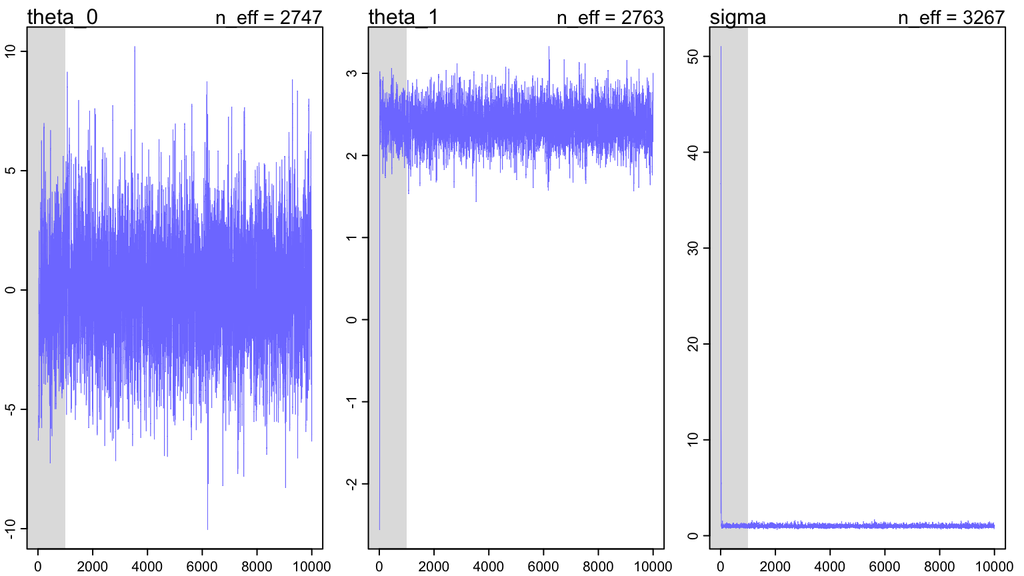

## Bayesian

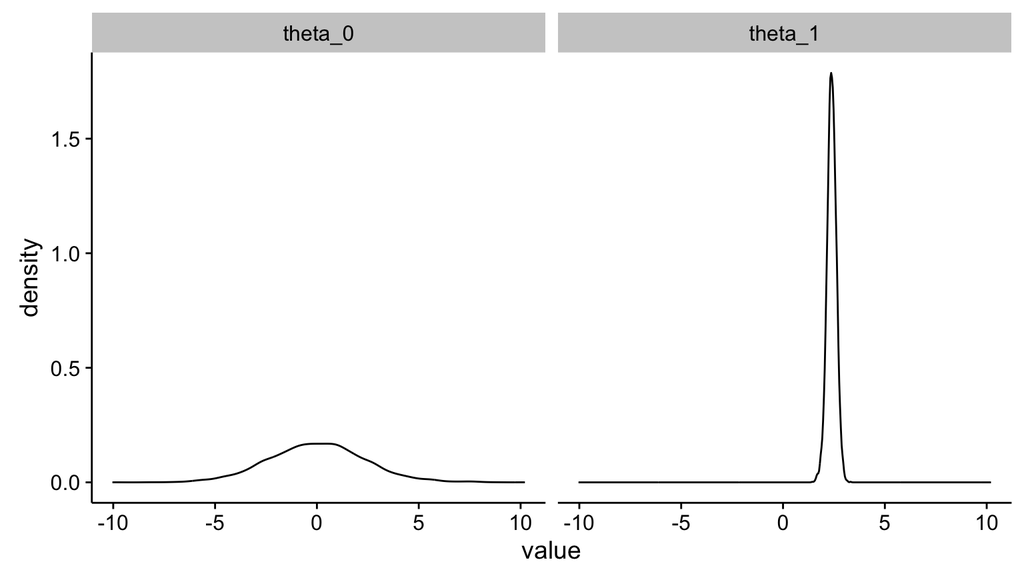

## Bayesian

```r
precis(fm, digits = 4)
```

```
##           Mean StdDev lower 0.89 upper 0.89 n_eff Rhat
## theta_0 0.0219 2.3643    -3.7193     3.7068  2747    1
## theta_1 2.3898 0.2250     2.0420     2.7512  2763    1
## sigma   0.9956 0.1359     0.7904     1.2129  3267    1
```

```r
coef(lm(Y ~ X, data = M))
```

```
## (Intercept)           X
## -0.03540546  2.39524849
```

## Bayesian

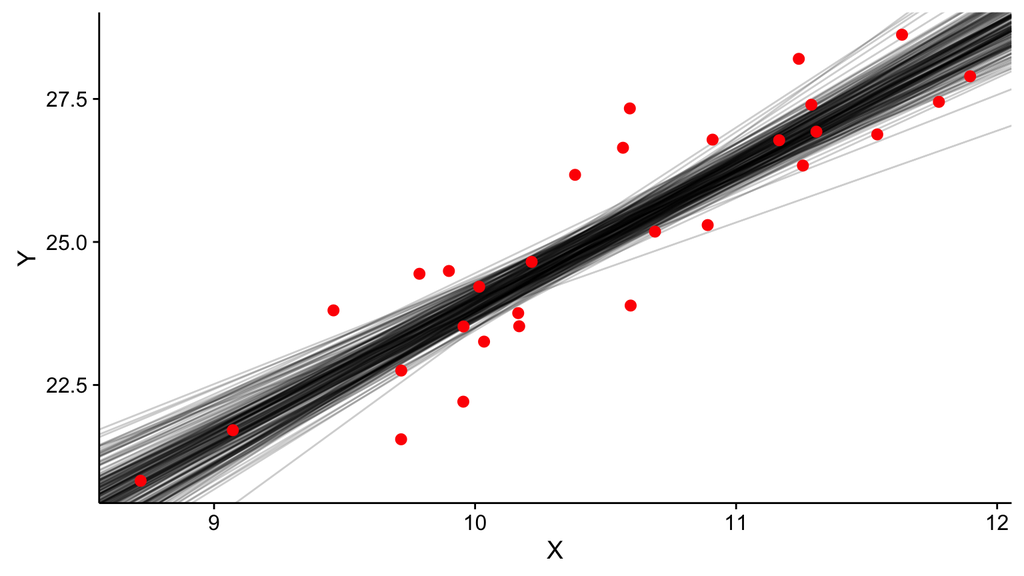

## Key features

- Analytical solutions are fast, hand-calculable
  - Unavailable for complex models (e.g., hierarchical models)
- Analytical and ML estimates will converge given enough precision
- Bayesian estimates can include prior knowledge
- Bayesian estimates will converge on ML estimates for sufficiently flat priors and/or sufficient data